# statistics

*solution_03_central_limit_theorem/01_standard_normal/03_centralarea_from_z_v2*

First, you need to identify that we are looking for a central area. This is because $z$-scores near 0 satisfy $|Z|<0.56$, while $z$-scores far from 0 (either positive or negative) do not satisfy the inequality.

Start with a sketch.

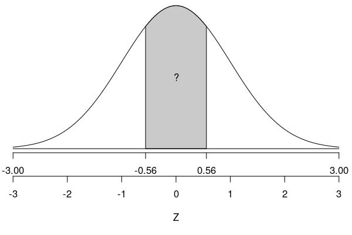

Remember, the entire area is always 1. Most z-tables only provide left areas, so three methods are shown to get the central area from a left-area (cumulative probability) table.

**Method 1:** First find the area of the left tail.
$$P(Z<-0.56) = 0.2877$$
Recognize normal distributions are symmetric, so we also know the area of the right tail.
$$P(Z>0.56) = 0.2877$$
The three areas add to 1.
$$\begin{aligned}
P\left(|Z|<0.56\right) &= 1-P(Z<-0.56)-P(Z>0.56) \\
&= 1 - 0.2877 - 0.2877 \\
&= 0.4246
\end{aligned}$$

This technique can be summarized with the following formula:
$$P\left(|Z|<z\right) = 1-2\cdot P(Z<-z)$$
assuming $z>0$.

So, in our case (when $z=0.56$),
$$\begin{aligned}
P\left(|Z|<0.56\right) &= 1-2\cdot P(Z<-0.56) \\
&= 1-2\cdot0.2877 \\
&= 0.4246
\end{aligned}$$

This method is shown graphically:

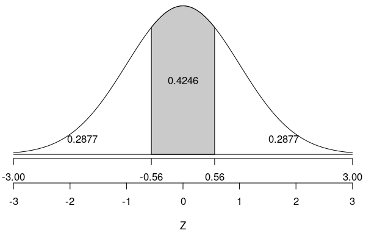

**Method 2:** You can also find half of the central area and then double it.
$$\begin{aligned}
P\left(|Z|<z\right) &= 2\cdot\left[ P(Z<z)-0.5\right] \\
&= 2\cdot\left[ 0.7123-0.5\right] \\
&= 2\cdot\left[ 0.2123\right] \\
&= 0.4246
\end{aligned}$$

This method is shown graphically:

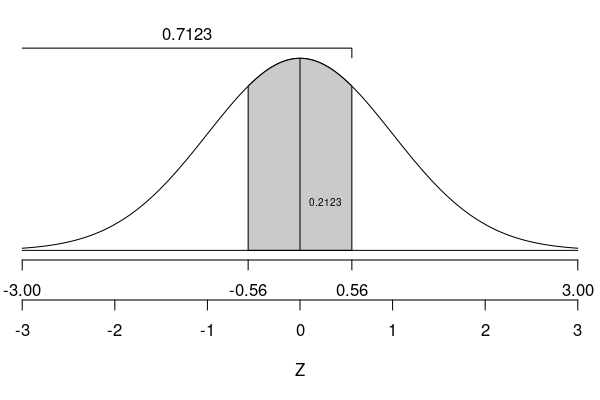

**Method 3:** You can also calculate the central area with a difference of two left areas.

$$\begin{aligned}
P\left(|Z|<0.56\right) &= P(Z<0.56)-P(Z<-0.56)\\
&= 0.7123-0.2877 \\
&= 0.4246
\end{aligned}$$

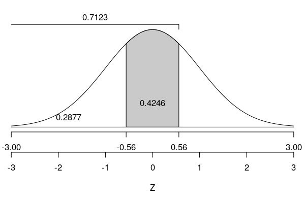

It might be helpful to visualize with a spinner.

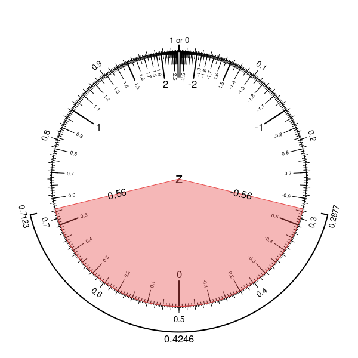

In a spreadsheet, you could use the `NORM.DIST()` function.

```
=NORM.DIST(0.56,0,1,TRUE) - NORM.DIST(-0.56,0,1,TRUE)
```

In R, you could use the `pnorm` function.

```
pnorm(0.56) - pnorm(-0.56)
```